# US Best Low Cost Vacation Destinations

Team 4, Cohrent A

Luke Towers, Yanyue Fu, Ke Zang, Mandi Zhu, Yue Wu

2019/08/19

## Introduction

We are analysing Air Bnb data for a low income family that have decided they want to travel within the US. They are a family of 4 who do not want to share rooms. They also do not want strict cancelation fee's in case they want to cancel last minute. They want to save as much money as possible but they want the best experience they can.

### Following are a few questions that we aim to answer through our analysis:

1. How many records are there in this airbnb dataset?
2. How cancelation policy would affect the average price of an Air Bnb?
3. Are hosts reponse time and the price of an Air Bnb correlated?
4. Will the popularity affect price of an Air Bnb?
5. What is the most common room type in US Air Bnb?
6. Do different types of room have different average price?
7. Which US cities have the highest average rating?
8. What is the distrubution of Air Bnb in each city??
9. How does average price of Air Bnb vary among cities? And choose two cities based on the average reviewing scores and avereage price.
10. Analyze the first city by adding the filter review_scores_rating
11. Analyze the first city by adding the filter review_scores_rating, number of accomadates and room type
12. Analyze the first city by adding the filter review_scores_rating, number of accomadates,room type and cancellation policy
13. Analyze the second city by adding the filter review_scores_rating
14. Analyze the second city by adding the filter review_scores_rating, number of accomadates and room type
15. Analyze the second city by adding the filter review_scores_rating, number of accomadates,room type and cancellation policy
16. Compare two cities and make final decision for the family
17. Some suggestions for travelling with low AirBnb charge.

## Description of Data

The data that we have decided to use is Air Bnb listin data from major cities in the US. These cities include San Francisco, New York City, Chicargo, Boston, Los Angeles and Washington DC. The data includes the following fields:

id - The identifyer of each data point

Log_Price - This is the natural log of the price per night of the accomodation.

Property_type - This is the kind of property it is e.g. House or apartment.

Room_type - This is the kind of room inside the accomodation e.g. Shared or private.

Accommodates - This is the number of people the property accommodates.

Bathrooms - This is the number of bathrooms in the property.

Bed_type - This is the type of bed e.g. Real bed or futon.

cancellation_policy - This is the owners policy on cancellations e.g. Strict/moderate/flexible.

Cleaning_fee - This is whether the owner charges a cleaning fee.

City - The location of the property.

First_review - This is the date of the first review of the property.

Host has profile pic - Whether the owner has a prfile pictire on file.

host_identity_verfication - This is whether the host has been verified by air bnb.

Host response rate - This is the response rate in percentage for each listing.

Instant_bookable - This is showing if you can book instantly through the app or website.

last_review - This is showing the date of last review of each listing.

Lat / Long - This is showing the coordinated of the listing.

Number of reviews - This is showing how many times the listing was reviewed.

Review score rating - Shows the average rating of each property out of 100.

Zipcode - Shows the zipcode of the listing.

Bedrooms - Shows the number of bedrooms of the listing.

Beds - Shows the number of beds in the listing.

Price - Shows the price per night.

#### Q1: How many records are there in this airbnb dataset?

(1) The raw dataset's link: https://www.kaggle.com/rudymizrahi/airbnb-listings-in-major-us-cities-deloitte-ml

```python
%%bq query
select * from `team-4-249220.project_1.airbnb_row_data`
```

(2) Firstly, add the 'normal price' to the table.

```python
%%bq query
create or replace table `team-4-249220.project_1.airbnb_last_final`
as
SELECT *, POWER(2.718, log_price) as price
FROM `team-4-249220.project_1.airbnb_row_data`
```

(3) Secondly, clean all NULL/NA in raw data.

```python
%%bq query
DELETE FROM `team-4-249220.project_1.airbnb_last_final`
where (log_price is null) or property_type is null or room_type is null or accommodates is null or bathrooms is null or bed_type is null or cancellation_policy is null or cleaning_fee is null or city is null or host_response_rate is null or instant_bookable is null or last_review is null or latitude is null or longitude is null or number_of_reviews is null or review_scores_rating is null or zipcode is null or bedrooms is null or beds is null or price is null
```

(4) This is the final dataset:

```python
%%bq query
SELECT * FROM `team-4-249220.project_1.airbnb_last_final`
```

| id | log_price | property_type | room_type | accommodates | bathrooms | bed_type | cancellation_policy | cleaning_fee | city | first_review | host_has_profile_pic | host_identity_verified | host_response_rate | host_since | instant_bookable | last_review | latitude | longitude | number_of_reviews | review_scores_rating | zipcode | bedrooms | beds | price |
| --- | --- | --- | --- | --- | --- | --- | --- | --- | --- | --- | --- | --- | --- | --- | --- | --- | --- | --- | --- | --- | --- | --- | --- | --- |
| 17972519 | 0.0 | Condominium | Shared room | 1 | 1.0 | Real Bed | strict | True | NYC | 2017-08-17 | True | False | 1.0 | 2017-07-20 | True | 2017-10-01 | 40.83805352 | -73.85866528 | 3 | 87 | 10462 | 1 | 1 | 1.0 |
| 3664261 | 4.634728988 | Apartment | Private room | 1 | 1.0 | Real Bed | flexible | False | NYC | 2015-09-27 | True | False | 1.0 | 2014-09-20 | True | 2017-09-30 | 40.76301961 | -73.9890467 | 170 | 90 | 10019 | 1 | 1 | 102.950515372 |
| 17047371 | 4.634728988 | Apartment | Private room | 1 | 1.0 | Real Bed | strict | False | NYC | 2017-03-28 | True | True | 1.0 | 2015-08-20 | False | 2017-09-22 | 40.74559982 | -74.00107482 | 10 | 98 | 10011 | 1 | 1 | 102.950515372 |
| 7785952 | 4.634728988 | Condominium | Private room | 1 | 1.0 | Real Bed | moderate | False | SF | 2016-01-13 | True | True | 1.0 | 2015-05-07 | False | 2017-07-22 | 37.77872131 | -122.4418654 | 42 | 99 | 94115 | 1 | 1 | 102.950515372 |
| 17796760 | 4.634728988 | Apartment | Private room | 1 | 1.0 | Airbed | flexible | False | NYC | 2015-04-05 | True | False | 0.9 | 2015-03-06 | False | 2017-07-04 | 40.75770387 | -73.99138413 | 32 | 92 | 10036 | 1 | 1 | 102.950515372 |
| 2272467 | 4.634728988 | Apartment | Private room | 1 | 1.0 | Real Bed | moderate | True | Boston | 2014-05-17 | True | True | 1.0 | 2012-08-23 | False | 2017-09-16 | 42.33409592 | -71.02828761 | 127 | 96 | 2127 | 1 | 1 | 102.950515372 |
| 4653799 | 4.634728988 | Apartment | Private room | 1 | 1.0 | Real Bed | strict | True | SF | 2012-06-29 | True | True | 1.0 | 2012-06-20 | False | 2017-06-14 | 37.76148735 | -122.4087381 | 149 | 97 | 94110 | 1 | 1 | 102.950515372 |
| 14371353 | 5.192956851 | Apartment | Entire home/apt | 1 | 1.0 | Real Bed | strict | True | NYC | 2013-05-15 | True | False | 0.5 | 2013-01-09 | False | 2015-09-08 | 40.77003421 | -73.95938204 | 3 | 90 | 10021 | 0 | 1 | 179.903109076 |
| 20253319 | 5.192956851 | Apartment | Private room | 1 | 1.0 | Airbed | strict | True | SF | 2015-04-24 | True | False | 1.0 | 2015-02-11 | True | 2017-09-26 | 37.7778584 | -122.4117759 | 31 | 97 | 94103 | 1 | 1 | 179.903109076 |
| 16960716 | 5.192956851 | Apartment | Private room | 1 | 2.0 | Real Bed | flexible | False | NYC | 2012-03-28 | True | True | 1.0 | 2012-02-06 | False | 2017-03-31 | 40.76666134 | -73.98036153 | 9 | 100 | 10019 | 1 | 1 | 179.903109076 |
| 9216587 | 5.192956851 | Apartment | Entire home/apt | 1 | 1.0 | Real Bed | flexible | True | LA | 2017-02-06 | True | True | 0.9 | 2015-02-01 | False | 2017-03-16 | 34.07172685 | -118.3683681 | 4 | 80 | 90048 | 1 | 1 | 179.903109076 |
| 10884260 | 5.192956851 | Apartment | Private room | 1 | 1.0 | Real Bed | moderate | True | NYC | 2015-09-16 | True | False | 1.0 | 2014-11-20 | False | 2017-09-20 | 40.77062689 | -73.98082727 | 22 | 99 | 10023 | 1 | 1 | 179.903109076 |
| 13896200 | 5.192956851 | Apartment | Entire home/apt | 1 | 1.0 | Real Bed | moderate | True | SF | 2017-08-31 | True | False | 1.0 | 2014-09-23 | False | 2017-09-30 | 37.77572887 | -122.3966065 | 2 | 100 | 94107 | 0 | 1 | 179.903109076 |
| 5507980 | 5.192956851 | Loft | Private room | 1 | 1.5 | Futon | strict | True | SF | 2015-06-14 | True | True | 1.0 | 2012-04-16 | False | 2016-01-15 | 37.77681134 | -122.3971976 | 4 | 100 | 94107 | 1 | 1 | 179.903109076 |
| 8539318 | 5.192956851 | Apartment | Private room | 1 | 1.0 | Real Bed | flexible | False | NYC | 2016-02-27 | True | True | 1.0 | 2012-02-06 | False | 2016-11-23 | 40.76688683 | -73.98032224 | 4 | 100 | 10019 | 1 | 1 | 179.903109076 |
| 9976626 | 4.276666119 | Apartment | Private room | 1 | 1.0 | Real Bed | flexible | True | NYC | 2016-04-17 | True | True | 0.9 | 2013-01-19 | False | 2017-08-22 | 40.72287933 | -73.98454184 | 2 | 90 | 10009 | 1 | 1 | 71.9680806196 |
| 5624807 | 4.276666119 | Apartment | Private room | 1 | 1.0 | Real Bed | flexible | True | NYC | 2014-06-02 | True | True | 1.0 | 2012-01-29 | False | 2017-09-26 | 40.85083772 | -73.94125415 | 43 | 95 | 10033 | 1 | 1 | 71.9680806196 |
| 7454629 | 4.276666119 | Apartment | Private room | 1 | 1.0 | Real Bed | flexible | True | LA | 2015-03-01 | True | True | 1.0 | 2014-07-26 | False | 2017-01-13 | 34.09513293 | -118.3625754 | 7 | 100 | 90046 | 1 | 1 | 71.9680806196 |
| 5284341 | 4.276666119 | Apartment | Private room | 1 | 1.0 | Real Bed | strict | False | NYC | 2016-07-30 | True | True | 1.0 | 2012-05-01 | False | 2017-09-15 | 40.72759754 | -73.9834668 | 323 | 98 | 10009 | 1 | 1 | 71.9680806196 |
| 19673878 | 4.276666119 | Apartment | Private room | 1 | 1.0 | Real Bed | flexible | False | NYC | 2017-06-15 | True | False | 1.0 | 2015-12-15 | False | 2017-06-15 | 40.79857796 | -73.96498651 | 1 | 100 | 10025 | 1 | 1 | 71.9680806196 |
| 10476626 | 4.276666119 | House | Private room | 1 | 1.0 | Real Bed | moderate | True | SF | 2015-07-31 | True | True | 1.0 | 2013-05-24 | False | 2017-09-16 | 37.73403271 | -122.4466228 | 6 | 90 | 94127 | 1 | 1 | 71.9680806196 |
| 20652639 | 4.276666119 | House | Private room | 1 | 1.0 | Real Bed | flexible | True | Boston | 2014-09-16 | True | True | 1.0 | 2014-07-31 | True | 2017-10-03 | 42.2756372 | -71.12480042 | 35 | 97 | 2131 | 1 | 1 | 71.9680806196 |
| 6014961 | 4.276666119 | Townhouse | Private room | 1 | 1.0 | Real Bed | strict | True | LA | 2015-05-21 | True | False | 1.0 | 2015-04-01 | False | 2016-07-31 | 34.06930178 | -118.3464001 | 39 | 96 | 90036 | 1 | 1 | 71.9680806196 |
| 4541102 | 4.276666119 | Apartment | Private room | 1 | 1.0 | Real Bed | strict | False | NYC | 2016-10-31 | True | True | 1.0 | 2015-10-23 | False | 2017-01-02 | 40.69634166 | -73.92715286 | 3 | 87 | 11221 | 1 | 1 | 71.9680806196 |
| 8722841 | 4.276666119 | Apartment | Private room | 1 | 1.0 | Real Bed | flexible | False | Boston | 2015-09-02 | True | True | 0.9 | 2014-05-27 | False | 2015-09-02 | 42.31408312 | -71.09973817 | 1 | 80 | 2130 | 1 | 1 | 71.9680806196 |

(rows: 47246, time: 1.8s, 8MB processed, job: job_sjyXAtwBygxGClBkQ3Dyg2zd7dLh)

#### Q2:How cancelation policy would affect the average price of an Air Bnb?

We wanted to start by doing some exploratory queries to understand more about our data before we tackle our main case involving our family. We began by finding out how cancelation policy would affect the average price of an Air Bnb. From this we can see that the more flexible with cancelations the cheaper the price usually is.

```python
%%bq query
SELECT cancellation_policy, round(avg(price),1) AS avg_price,
case when avg(price) >= 174 then "Expensive"
     when avg(price) >= 110 then "Moderate"
     else "Cheap"
end as Price_classification
FROM `team-4-249220.project_1.airbnb_last_final`
group by cancellation_policy
ORDER BY avg_price;
```

| cancellation_policy | avg_price | Price_classification |
| --- | --- | --- |
| flexible | 114.9 | Moderate |
| moderate | 133.6 | Moderate |
| strict | 169.0 | Moderate |
| super_strict_30 | 263.3 | Expensive |
| super_strict_60 | 641.1 | Expensive |

(rows: 5, time: 0.9s, 802KB processed, job: job_cIKA-88vkZ7dXEAqWEvtc6BVCHOn)

#### Q3: Are hosts reponse time and the price of an Air Bnb correlated?

We decided to see if there was a correlation between the hosts response time and the price of an Air Bnb. From these results we generated a scatter plot to visulize the relationship. We can see that there is a very slight positive correlation. As the response rate increases the average price also very slightly increases. We can also see from the chart there are some outliers probably coming from small amounts of data at certain response rate data points.

```python
%%bq query -n Response_rate
SELECT host_response_rate , avg(price) AS avg_price  FROM `team-4-249220.project_1.airbnb_last_final`
group by host_response_rate;
```

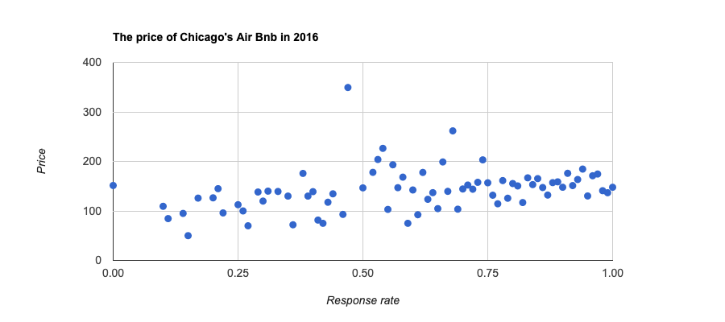

```python
%%chart scatter --data Response_rate
title: The price of Chicago's Air Bnb in 2016
height: 400
width: 900
hAxis:
  title: Response rate
vAxis:
  title: Price
legend: none
```

#### Q4: Will the popularity affect price of an Air Bnb?

Then we decided to look at how popularity affected price. We determined popularity by the number of reviews a certain accomodation has and we plotted this against price. You can see from the chart that popularity is highest at the lower prices. This makes sense when thinking about the customers using air bnb, usually trying to save money and not pay alot for hotels. This graph shows that the market for expensive air bnb listings is much smaller than cheaper listings.

```python
%%bq query -n review
select  price, number_of_reviews from `team-4-249220.project_1.airbnb_last_final`
order by price
```

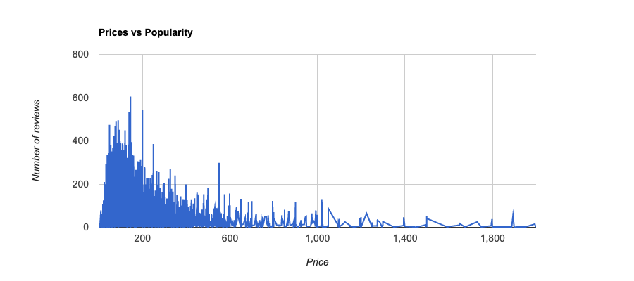

```python
%%chart line --data review
title: Prices vs Popularity
height: 400
width: 900
hAxis:
  title: Price
vAxis:
  title: Number of reviews
legend: none
```

#### Q5: What is the most common room type in US Air Bnb?

We also wanted to see what the most common types of rooms were amoungst Air bnbs, so we generated a pie chart to show what percentage each kind of room is. As you can see the shared room is considerably lower than all other types.

```python
%%bq query -n roomtype
-- Which is the most common room type?
SELECT room_type, count(room_type) as quantity
FROM `team-4-249220.project_1.airbnb_last_final`
group by room_type
order by count(room_type) desc;
```

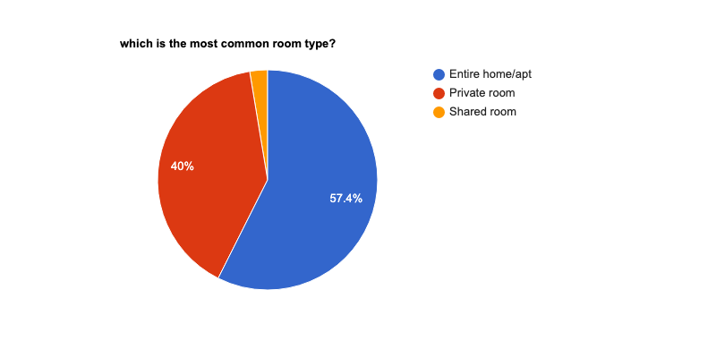

```python
%%chart pie --fields room_type,quantity --data roomtype
title: which is the most common room type?
height: 400
width: 800
```

#### Q6: Does different types of room have different price classification?

Following on price classification we can see shared room and private room are considerably cheap than Entire house/apt, and shared room is the cheapest room type among them.

```python
%%bq query
SELECT room_type, round(avg(Price),1) AS avg_price,
case when round(avg(Price),1) >= 174 then "Expensive"
     when round(avg(Price),1) >= 110 then "Moderate"
     else "Cheap"
end as Price_classification
FROM `team-4-249220.project_1.airbnb_last_final`
Group by room_type
Order by avg_price;
```

| room_type | avg_price | Price_classification |
| --- | --- | --- |
| Shared room | 49.4 | Cheap |
| Private room | 80.4 | Cheap |
| Entire home/apt | 200.6 | Expensive |

(rows: 3, time: 0.7s, 1MB processed, job: job_4JFC2ctKdfZJ3VykM0sh8pOwqTZc)

#### Sceneior Analysis

Now we wanted to explore a senario in which our family is a low income family that have decided they want to travel within the US. They are a family of 4 who do not want to share rooms. They also do not want strict cancelation fee's in case they want to cancel last minute. They want to save as much money as possible but they want the best experience they can.

#### Q7: Which US cities have the highest average rating?

First we analysed our whole data set in order to discover which cities had the highest average rating. Our family wanted to go somwhere that was rated highley but within their budget.

```python
%%bq query -n rating
select city, avg(review_scores_rating)as avgerage_rating
from `team-4-249220.project_1.airbnb_last_final`
group by city
order by avgerage_rating desc
```

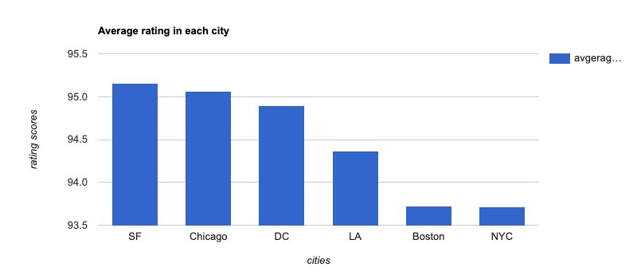

```python
%%chart columns --data rating
title: Average rating in each city
height: 350
width: 800
hAxis:
  title: cities
vAxis:
  title: rating scores
legend: None
```

#### Q8: What is the distrubution of Air Bnb in each city?

We then analysed the number of Air Bnb's in each city becasue our family wanted a large selection of accomodation to chosse from when deciding where to go.

```python
%%bq query -n num_air
SELECT city, count(id) AS Number_of_AirBnb   FROM `team-4-249220.project_1.airbnb_last_final`
GROUP BY city
ORDER BY Number_of_AirBnb DESC ;
```

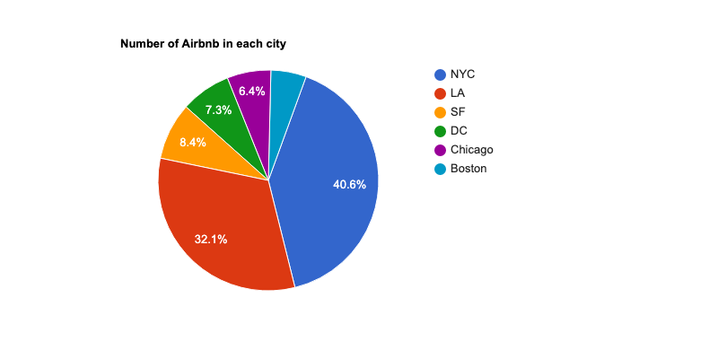

```python
%%chart pie --fields city,Number_of_AirBnb --data num_air
title: Number of Airbnb in each city
height: 400
width: 800
pieStartAngle: 20
slices:
  0:
    offset:
```

#### Q9: How does average price of Air Bnb vary among cities? And choose two cities for the family based on the average reviewing scores and avereage price.

We then analysed the avg price in each city, our family are low income and they wanted to stay in as cheaper accomodation as possible when traveling.

```python
%%bq query -n price
SELECT city, avg(price) AS avg_price FROM `team-4-249220.project_1.airbnb_last_final`
GROUP BY city
ORDER BY avg_price;
```

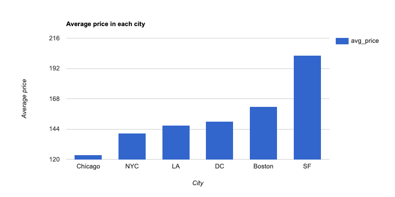

```python
%%chart columns --data price
title: Average price in each city
height: 400
width: 800
hAxis:
  title: City
vAxis:
  title: Average price
legend: None
```

Based on the average rating score and price rankings, Chicago and NewYork are the top best choice for family of four, since the Chicago has the lowest price among six cities and second hightest score rating and New York had the largest selection with the second lowest avg price.

#### Q10: Analyze the first city by adding the filter review_scores_rating

After determining the two cities that we decided to analyze based on price, and rating we decided to find the lowest average price based on the zipcodes within each city. We then limit this to 3 results. We also added a constraint that makes the average rating above 90. Although the family is trying to save money, they also want to stay somwhere with good quality and safety. This first set of analysis is on the city of Chicargo.

```python
%%bq query
select zipcode, round(avg(review_scores_rating),2) as average_rating, round(avg(price),1) as price
from `team-4-249220.project_1.airbnb_last_final`
where city = 'Chicago'
group by zipcode
having avg(review_scores_rating) >= 90
order by price
LIMIT 3
```

| zipcode | average_rating | price |
| --- | --- | --- |
| 60629 | 96.57 | 42.4 |
| 60302 | 93.0 | 42.5 |
| 60660-1448 | 99.0 | 44.0 |

(rows: 3, time: 0.5s, 1MB processed, job: job_24imwAlQ3MwzSgKVJoB6uc1jLw_I)

#### Q11: Analyze the first city by adding the filter review_scores_rating, number of accomadates and room type

Next, we added a constraint that the booking must accomodate 4 or more. This is becasue our family consist of 4 members. We also added that the room type should NOT be shared, as the members of the family would not want to be sharing a room.

```python
%%bq query
select zipcode, round(avg(review_scores_rating),2) as average_rating, round(avg(price),1) as price
from `team-4-249220.project_1.airbnb_last_final`
where city = 'Chicago' and accommodates >=4 and room_type != 'Shared room'
group by zipcode
having avg(review_scores_rating) >= 90
order by price
LIMIT 3
```

| zipcode | average_rating | price |
| --- | --- | --- |
| 60652 | 92.0 | 33.0 |
| 60638 | 99.0 | 62.5 |
| 60623 | 90.21 | 64.4 |

(rows: 3, time: 0.7s, 2MB processed, job: job__VwXgyKx42TIbZXlElJMgJufWHTf)

#### Q12: Analyze the first city by adding the filter review_scores_rating, number of accomadates, room type and cancellation policy

```python
%%bq query
create or replace table `team-4-249220.project_1.table_1` as
select zipcode, round(avg(review_scores_rating),2) as average_rating, round(avg(price),1) as price
from `team-4-249220.project_1.airbnb_last_final`
where city = 'Chicago' and accommodates >=4 and room_type != 'Shared room' and cancellation_policy in( 'flexible', 'moderate' )
group by zipcode
having avg(review_scores_rating) >= 90
order by price
```

| zipcode | average_rating | price |
| --- | --- | --- |
| 60632 | 100.0 | 63.0 |
| 60624 | 90.38 | 72.6 |
| 60656 | 97.0 | 75.0 |
| 60643 | 96.5 | 77.5 |
| 60638 | 100.0 | 80.0 |
| 60609 | 98.0 | 82.3 |
| 60651 | 93.0 | 88.8 |
| 60649 | 100.0 | 89.0 |
| 60644 | 94.5 | 93.5 |
| 60630 | 91.75 | 94.5 |
| 60639 | 99.67 | 97.6 |
| 60608 | 93.87 | 102.3 |
| 60646 | 98.5 | 102.5 |
| 60634 | 95.0 | 104.9 |
| 60602 | 92.0 | 109.9 |
| 60619 | 95.0 | 109.9 |
| 60641 | 96.33 | 123.6 |
| 60625 | 97.0 | 124.5 |
| 60618 | 96.05 | 124.6 |
| 60660 | 97.29 | 130.9 |
| 60626 | 93.25 | 133.1 |
| 60631 | 96.0 | 134.4 |
| 60615 | 91.89 | 138.4 |
| 60640 | 96.42 | 138.4 |
| 60647 | 95.08 | 140.8 |

(rows: 41, time: 1.2s, 2MB processed, job: job_dU98mdJV3iVQ6FEExLnGrBG_unnr)

Still, the number of AirBnb available for customers and the number of review are two key factors for customers when they make a final decision. This table will display these two factors in each area in Chicago. This table called 'table_2'.

```python
%%bq query
CREATE OR REPLACE table `team-4-249220.project_1.table_2`
as
with rating as (select review_scores_rating from `team-4-249220.project_1.airbnb_last_final` where review_scores_rating >= 90)
select zipcode, count(*)as number_of_airbnb, avg(number_of_reviews) as number_of_review from `team-4-249220.project_1.airbnb_last_final`
where city = "Chicago" and review_scores_rating in (select * from rating)
group by zipcode
order by count(*) desc
```

| zipcode | number_of_airbnb | number_of_review |
| --- | --- | --- |
| 60622 | 260 | 36.4423076923 |
| 60647 | 258 | 38.9651162791 |
| 60657 | 196 | 32.4285714286 |
| 60614 | 164 | 29.9207317073 |
| 60618 | 144 | 34.5763888889 |
| 60613 | 133 | 22.8646616541 |
| 60640 | 119 | 28.9579831933 |
| 60608 | 114 | 35.6140350877 |
| 60642 | 105 | 34.3238095238 |
| 60610 | 99 | 32.8787878788 |
| 60612 | 78 | 34.9230769231 |
| 60616 | 74 | 30.9864864865 |
| 60601 | 67 | 26.4925373134 |
| 60626 | 63 | 29.1428571429 |
| 60611 | 62 | 25.1774193548 |
| 60660 | 60 | 35.4666666667 |
| 60615 | 59 | 29.9152542373 |
| 60625 | 59 | 26.8305084746 |
| 60653 | 51 | 18.1764705882 |
| 60654 | 49 | 25.8979591837 |
| 60605 | 48 | 23.4375 |
| 60641 | 46 | 24.0869565217 |
| 60607 | 39 | 38.4102564103 |
| 60637 | 36 | 33.8611111111 |
| 60602 | 32 | 34.71875 |

(rows: 57, time: 1.6s, 1MB processed, job: job_05ZMN6yDCdyKrAiI-FsZHlOkeq_q)

To double check our result in Chicago, we'll join table_1 and table_2 together. As shown below, it proves that this family should book the Airbnb in '60632' if they prefer to travel in Chicago.

```python
%%bq query
SELECT A.zipcode, average_rating, price, number_of_airbnb, number_of_review
FROM `team-4-249220.project_1.table_1` as A
left join
`team-4-249220.project_1.table_2` as B
on A.zipcode = B.zipcode
order by price, average_rating desc, number_of_airbnb, number_of_review
limit 5
```

| zipcode | average_rating | price | number_of_airbnb | number_of_review |
| --- | --- | --- | --- | --- |
| 60632 | 100.0 | 63.0 | 5 | 20.2 |
| 60624 | 90.38 | 72.6 | 17 | 72.5882352941 |
| 60656 | 97.0 | 75.0 | 5 | 51.4 |
| 60643 | 96.5 | 77.5 | 5 | 56.6 |
| 60638 | 100.0 | 80.0 | 3 | 23.6666666667 |

(rows: 5, time: 0.5s, 2KB processed, job: job_9SOE-zNV3CnddGyMGu8xrbv_wP_J)

#### Q13: Analyze the second city by adding the filter review_scores_rating

We then ran the same queries with NYC as the city of choice.

```python
%%bq query
select zipcode, round(avg(review_scores_rating),2) as average_rating, round(avg(price),1) as price
from `team-4-249220.project_1.airbnb_last_final`
where city = 'NYC'
group by zipcode
having avg(review_scores_rating) >= 90
order by price
LIMIT 3
```

| zipcode | average_rating | price |
| --- | --- | --- |
| 11423 | 96.0 | 22.0 |
| 10474 | 93.71 | 47.3 |
| 10472 | 93.93 | 48.3 |

(rows: 3, time: 0.4s, cached, job: job_zBZowNwcDakNUk3B3opYOoU7lI7w)

#### Q14: Analyze the second city by adding the filter review_scores_rating, number of accomadates and room type

```python
%%bq query
select zipcode, round(avg(review_scores_rating),2) as average_rating, round(avg(price),1) as price
from `team-4-249220.project_1.airbnb_last_final`
where city = 'NYC' and accommodates >=4 and room_type != 'Shared room'
group by zipcode
having avg(review_scores_rating) >= 90
order by price
LIMIT 3
```

| zipcode | average_rating | price |
| --- | --- | --- |
| 10472 | 98.0 | 60.0 |
| 10456 | 95.0 | 75.0 |
| 10470 | 93.0 | 76.0 |

(rows: 3, time: 0.6s, 2MB processed, job: job_SfmYN7KxSTNgyee-TGeWTTeKM7Qw)

#### Q15: Analyze the second city by adding the filter review_scores_rating, number of accomadates,room type and cancellation policy

(1) Create 'table_3'

```python
%%bq query
create or replace table `team-4-249220.project_1.table_3` as
select zipcode, round(avg(review_scores_rating),2) as average_rating, round(avg(price),1) as price
from `team-4-249220.project_1.airbnb_last_final`
where cancellation_policy in ('flexible','moderate')  and city = 'NYC' and accommodates >=4 and room_type != 'Shared room'
group by zipcode
having avg(review_scores_rating) >= 90
order by price
```

| zipcode | average_rating | price |
| --- | --- | --- |
| 11694 | 97.0 | 50.0 |
| 10455 | 91.5 | 60.0 |
| 10472 | 98.0 | 60.0 |
| 11210 | 91.67 | 68.3 |
| 11429 | 99.5 | 70.0 |
| 10308 | 96.5 | 78.0 |
| 11416 | 95.0 | 79.0 |
| 11385 | 94.06 | 84.1 |
| 10469 | 99.0 | 84.5 |
| 11421 | 92.0 | 85.0 |
| 10464 | 95.5 | 91.5 |
| 10454 | 94.75 | 92.7 |
| 10465 | 97.0 | 94.0 |
| 11691 | 92.33 | 95.0 |
| 11368 | 97.38 | 96.1 |
| 11412 | 95.0 | 97.7 |
| 11212 | 95.5 | 98.0 |
| 10305 | 92.0 | 100.2 |
| 11367 | 96.0 | 101.3 |
| 11230 | 96.86 | 101.5 |
| 11418 | 91.5 | 101.7 |
| 11354 | 97.17 | 101.8 |
| 10040 | 95.44 | 102.9 |
| 11224 | 97.0 | 103.0 |
| 11434 | 95.6 | 104.1 |

(rows: 133, time: 1.7s, 2MB processed, job: job_v4z7GPyGMOPu7TuHZdufxynV-STr)

(2) Create 'table_4' which shows the number of airbnb and number of the review in each area in NYC

```python
%%bq query
CREATE OR REPLACE table `team-4-249220.project_1.table_4`
as
with rating as (select review_scores_rating from `team-4-249220.project_1.airbnb_last_final` where review_scores_rating >= 90)
select zipcode, count(*)as number_of_airbnb, round(avg(number_of_reviews)) as number_of_review from `team-4-249220.project_1.airbnb_last_final`
where city = "NYC" and review_scores_rating in (select * from rating)
group by zipcode
order by count(*) desc
```

| zipcode | number_of_airbnb | number_of_review |
| --- | --- | --- |
| 11211 | 834 | 31.0 |
| 11221 | 610 | 27.0 |
| 11216 | 478 | 28.0 |
| 10002 | 464 | 29.0 |
| 11206 | 457 | 28.0 |
| 11238 | 446 | 27.0 |
| 10009 | 412 | 31.0 |
| 10019 | 388 | 34.0 |
| 10003 | 366 | 29.0 |
| 11222 | 364 | 23.0 |
| 10036 | 339 | 35.0 |
| 11237 | 332 | 24.0 |
| 10011 | 326 | 26.0 |
| 11215 | 324 | 32.0 |
| 10027 | 309 | 30.0 |
| 10031 | 302 | 31.0 |
| 11233 | 300 | 36.0 |
| 10014 | 292 | 26.0 |
| 11249 | 291 | 26.0 |
| 10029 | 277 | 36.0 |
| 10012 | 274 | 30.0 |
| 10025 | 255 | 27.0 |
| 11226 | 250 | 24.0 |
| 11205 | 246 | 25.0 |
| 11217 | 214 | 34.0 |

(rows: 187, time: 1.6s, 1MB processed, job: job_hZJFyS9vgDu-VYnHBoNyk4Rdaxft)

(3) Condisering all factors (average_rating, price, number of airbnb, number of review), this family should book the Airbnb in '10467' if they prefer to travel in NYC.

```python
%%bq query
SELECT A.zipcode, average_rating, price, number_of_airbnb, number_of_review
FROM `team-4-249220.project_1.table_3` as A
left join
`team-4-249220.project_1.table_4` as B
on A.zipcode = B.zipcode
order by average_rating desc, price, number_of_airbnb, number_of_review
limit 5
```

| zipcode | average_rating | price | number_of_airbnb | number_of_review |
| --- | --- | --- | --- | --- |
| 10467 | 100.0 | 112.9 | 13 | 14.0 |
| 10306 | 100.0 | 124.9 | 9 | 11.0 |
| 11413 | 100.0 | 149.4 | 15 | 51.0 |
| 11363 | 100.0 | 149.9 | 2 | 10.0 |
| 10471 | 100.0 | 149.9 | 5 | 9.0 |

(rows: 5, time: 0.5s, 7KB processed, job: job_3Q37KR6U7dbvcGtD7Uvn1OcI2T56)

#### Q16: Compare two cities and make final decision for the family

We then combined the top result from each of the queries and the family decided that they wanted to go the Air Bnb with the lower price from the 2 choices. The family has decided they will go to Chicago where they will stay in the zipcode '60632' for $63 a night.

```python
%%bq query
(SELECT A.zipcode, average_rating, price, number_of_airbnb, number_of_review
FROM `team-4-249220.project_1.table_1` as A
left join
`team-4-249220.project_1.table_2` as B
on A.zipcode = B.zipcode
order by average_rating desc, price, number_of_airbnb, number_of_review
limit 1)
UNION ALL
(SELECT A.zipcode, average_rating, price, number_of_airbnb, number_of_review
FROM `team-4-249220.project_1.table_3` as A
left join
`team-4-249220.project_1.table_4` as B
on A.zipcode = B.zipcode
order by average_rating desc, price, number_of_airbnb, number_of_review
limit 1);
```

[output not shown]

(rows: 2, time: 0.6s, 9KB processed, job: job_t-s8yoZTqSYFzDLaq41NWgOqXtL7)

#### Q17: Some suggestions for travelling with low AirBnb charge.

(1) Travelling to Chicago: Christmas holiday and Easter holiday would be the best time to go to Chicago and make sure to avoid travelling to there in Summer holiday.

```python
%%bq query -n time
with rating as (select review_scores_rating from `team-4-249220.project_1.airbnb_last_final` where review_scores_rating >= 90)
select extract(month from last_review) as the_month, round(avg(price),2) as avg_price
from `team-4-249220.project_1.airbnb_last_final`
where city = 'Chicago' and review_scores_rating in (select * from rating)
group by the_month
order by the_month
```

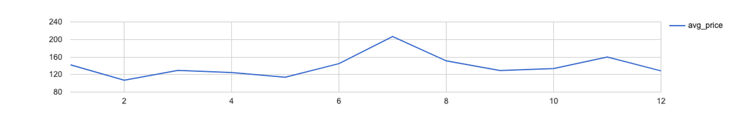

```python
%%chart line --data time
```

```python
%%bq query -n time
with rating as (select review_scores_rating from `team-4-249220.project_1.airbnb_last_final` where review_scores_rating >= 90)
select extract(month from last_review) as the_month, round(avg(price),2) as avg_price
from `team-4-249220.project_1.airbnb_last_final`
where city = 'NYC' and review_scores_rating in (select * from rating)
group by the_month
order by the_month
```

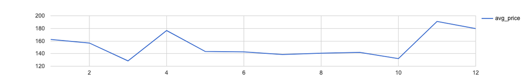

```python
%%chart line --data time
```

#### Q18: Using BQML to predict the Air Bnb price in Chicago and NYC

(1) NYC-Model

```python
%%bq query
CREATE OR REPLACE MODEL project_1.price_model_NYC
OPTIONS
   (model_type='linear_reg', labels=['price']) AS

WITH room_type_dummy AS (
 	SELECT
    	price AS price_room_type,
    	CASE WHEN room_type='Private room' THEN 1
         	ELSE 0 END AS private_room,
    	CASE WHEN room_type='Entire_home/apt' THEN 1
         	ELSE 0 END AS entire_home
    	FROM `team-4-249220.project_1.airbnb_last_final` ),

 	can_policy_dummy AS (
 	SELECT
     	price AS price_can_policy,
     	CASE WHEN cancellation_policy ='flexible' THEN 1
          	ELSE 0 END AS flexible,
     	CASE WHEN cancellation_policy ='moderate' THEN 1
          	ELSE 0 END AS moderate,
     	CASE WHEN cancellation_policy='super_strict_30' THEN 1
          	ELSE 0 END AS super_strict_30,
     	CASE WHEN cancellation_policy='super_strict_60' THEN 1
          	ELSE 0 END AS super_strict_60
     	FROM `team-4-249220.project_1.airbnb_last_final`)

SELECT price, private_room, entire_home,flexible, moderate, super_strict_30, super_strict_60,  accommodates, latitude, longitude, number_of_reviews, review_scores_rating, bedrooms
FROM room_type_dummy, can_policy_dummy, `team-4-249220.project_1.airbnb_last_final`
WHERE city='NYC'
LIMIT 47244
```

Done

(2) NYC-Predict

```python
%%bq query
SELECT
*
FROM
  ml.PREDICT(MODEL `team-4-249220.project_1.price_model_NYC`,
	(
	WITH room_type_dummy AS (
 	SELECT
    	price AS price_room_type,
    	CASE WHEN room_type='Private room' THEN 1
         	ELSE 0 END AS private_room,
    	CASE WHEN room_type='Entire_home/apt' THEN 1
         	ELSE 0 END AS entire_home
    	FROM `team-4-249220.project_1.airbnb_last_final` ),

     can_policy_dummy AS (
 	SELECT
     	price AS price_can_policy,
     	CASE WHEN cancellation_policy ='flexible' THEN 1
          	ELSE 0 END AS flexible,
     	CASE WHEN cancellation_policy ='moderate' THEN 1
          	ELSE 0 END AS moderate,
     	CASE WHEN cancellation_policy='super_strict_30' THEN 1
          	ELSE 0 END AS super_strict_30,
     	CASE WHEN cancellation_policy='super_strict_60' THEN 1
          	ELSE 0 END AS super_strict_60
     	FROM `team-4-249220.project_1.airbnb_last_final`)

SELECT price, private_room, entire_home,flexible, moderate, super_strict_30, super_strict_60,
   	accommodates, latitude, longitude, number_of_reviews, review_scores_rating, bedrooms
FROM room_type_dummy, can_policy_dummy, `team-4-249220.project_1.airbnb_last_final`
WHERE city='NYC'
LIMIT 47244
))
```

| predicted_price | price | private_room | entire_home | flexible | moderate | super_strict_30 | super_strict_60 | accommodates | latitude | longitude | number_of_reviews | review_scores_rating | bedrooms |
| --- | --- | --- | --- | --- | --- | --- | --- | --- | --- | --- | --- | --- | --- |
| 113.527442828 | 179.903109076 | 1 | 0 | 0 | 0 | 0 | 0 | 1 | 40.76666134 | -73.98036153 | 9 | 100 | 1 |
| 124.356414251 | 71.9680806196 | 1 | 0 | 0 | 0 | 0 | 0 | 1 | 40.74033627 | -74.00258813 | 8 | 100 | 1 |
| 98.0868915417 | 164.912671106 | 1 | 0 | 0 | 0 | 0 | 0 | 1 | 40.79572174 | -73.94809824 | 2 | 100 | 1 |
| 98.5552994709 | 124.9374381 | 1 | 0 | 0 | 0 | 0 | 0 | 1 | 40.74691394 | -73.98072338 | 52 | 91 | 1 |
| 93.837458723 | 124.9374381 | 1 | 0 | 0 | 0 | 0 | 0 | 1 | 40.7201895 | -73.98217453 | 71 | 97 | 1 |
| 27.1566101256 | 59.9745342445 | 1 | 0 | 0 | 0 | 0 | 0 | 1 | 40.70626353 | -73.95211594 | 3 | 73 | 0 |
| 86.7236953756 | 83.9614187712 | 1 | 0 | 0 | 0 | 0 | 0 | 1 | 40.71457568 | -73.95002083 | 2 | 100 | 1 |
| 104.86923093 | 119.940448297 | 1 | 0 | 0 | 0 | 0 | 0 | 1 | 40.804607 | -73.95624602 | 2 | 100 | 1 |
| 113.534777887 | 119.940448297 | 1 | 0 | 0 | 0 | 0 | 0 | 1 | 40.71345654 | -73.99196501 | 6 | 100 | 1 |
| 151.176350804 | 42.9832342589 | 1 | 0 | 0 | 0 | 0 | 0 | 1 | 40.60609064 | -74.08880268 | 3 | 73 | 1 |
| 81.3449503585 | 42.9832342589 | 1 | 0 | 0 | 0 | 0 | 0 | 1 | 40.81524159 | -73.94751202 | 81 | 91 | 1 |
| 95.4781192923 | 37.985670615 | 1 | 0 | 0 | 0 | 0 | 0 | 1 | 40.85118996 | -73.94245332 | 1 | 80 | 1 |
| 121.17211991 | 174.906311364 | 1 | 0 | 0 | 0 | 0 | 0 | 1 | 40.73530468 | -74.00524659 | 21 | 96 | 1 |
| 79.574931202 | 40.9842164514 | 1 | 0 | 0 | 0 | 0 | 0 | 1 | 40.64190105 | -73.96420576 | 5 | 88 | 1 |
| 53.3590728779 | 22.992523884 | 1 | 0 | 0 | 0 | 0 | 0 | 1 | 40.61588178 | -73.94612977 | 2 | 60 | 1 |
| 82.0339885482 | 22.992523884 | 1 | 0 | 0 | 0 | 0 | 0 | 1 | 40.79337091 | -73.93995823 | 11 | 78 | 1 |
| -58.9166552845 | 34.9871001822 | 1 | 0 | 0 | 0 | 0 | 0 | 1 | 40.6960448 | -73.82448851 | 288 | 95 | 1 |
| 82.9456309606 | 34.9871001822 | 1 | 0 | 0 | 0 | 0 | 0 | 1 | 40.68638767 | -73.95548072 | 15 | 99 | 1 |
| 110.960854824 | 99.9522630275 | 1 | 0 | 0 | 0 | 0 | 0 | 1 | 40.72930244 | -73.98283484 | 1 | 100 | 1 |
| 112.666734805 | 99.9522630275 | 1 | 0 | 0 | 0 | 0 | 0 | 1 | 40.74295026 | -73.99778058 | 35 | 91 | 1 |
| 58.6042162413 | 99.9522630275 | 1 | 0 | 0 | 0 | 0 | 0 | 1 | 40.75708204 | -73.9896655 | 297 | 96 | 1 |
| 94.9664687341 | 84.9608551649 | 1 | 0 | 0 | 0 | 0 | 0 | 1 | 40.68863788 | -73.9766913 | 23 | 97 | 1 |
| 79.9768954099 | 38.9851885132 | 1 | 0 | 0 | 0 | 0 | 0 | 1 | 40.7755822 | -73.92854182 | 12 | 100 | 1 |
| 117.014633329 | 79.9636605031 | 1 | 0 | 0 | 0 | 0 | 0 | 1 | 40.70537802 | -74.01043539 | 26 | 91 | 1 |
| 84.0202091904 | 79.9636605031 | 1 | 0 | 0 | 0 | 0 | 0 | 1 | 40.76026219 | -73.96590292 | 101 | 99 | 1 |

(rows: 47244, time: 7.8s, 4MB processed, job: job_jcZat0QeaxWNChi5BxAf9qL0QjbQ)

## Summary

In summary through runnnig our queries in the database we were able to determine the best travel city for our case family based on a number of constraints. Using this method allows us to not only solve problems for this case but also any number of senarios and constraints that a client or customer might give us finding the best place to stay for them.